# Trends of Twitch API data

## Goal: help product manager better understanding of:

- which application developers are important to the developer ecosystem
- which API endpoints are more important to continue to maintain

### Dataset Description

Jan 2018

1. daily_logs.csv – contains the daily API call logs for different applications calling the Twitch API:
   - the_date: the date of the Twitch API
   - client_id: the internal id of a given application calling the Twitch API
   - api_endpoint: the name of a specific Twitch API call, see notes on api_endpoint in the next section for important information about this field
   - num_requests: the total number of times the API call was requested by an application
   - avg_latency: the average latency (in milliseconds) of the API call(smaller latency time, faster getting in API)
2. app_metadata.csv – contains a mapping of client_id to human readable application names:
   - client_id: the internal id of a given application calling the Twitch API
   - application_name: the name of the application chosen by the application developer
   - application_author: the name of the application developer

The structure of an api_endpoint is the following: {http_request_method} /{twitch_api_version}/{api_endpoint_method} Examples of http_request_method will include GET, POST, PUT, DELETE.

Examples of twitch_api_version include /v3, /v5, and /helix. Note that v3 and v5 versions are old versions of the API, and will be removed on Dec 2018. Helix is the codename of the new Twitch API. Note that different API versions can have the same API endpoint method name.

Examples of api_endpoint_method are numerous, but at a high level they allow the developerto do things like “get metadata on a specific video clip” or “get a list of who is following streamer X”.

## Initial Analysis

Since we want to find the important developer and API endpoint, we first need to define important. According to available data, there are two metrics(num_requests/avg_latency) we can use to measure how importance one application is.

- num_requests: shows how popular one application is. The larger number of requests is, the more important the application(endpoint) is. Or if an application shows rapid increase in num_requests, it also indicates this application is increasingly important
- avg_latency: show how fast clients get response, it measures how well the system is. Larger latency would increase frustration and negative feedback from clients, we want applications with smaller latency time. That is, applications with **larger num_requests and smaller avg_latency preform better and are what we desire**, thus **the developer owns those applications are more important to the developer ecosystem**.

For important API endpoints, we also assume **popular endpoints(most frequently used & showing increasing trends) are more important, because those API are core products of our company. Especially those popular endpoints with longer latency time, are deserved more effort to maintain and improve.** Besides, endpoints with continuous use in the future are more important than those with soonly removement.

Sum up, we need to find **developers with most frequently used and less latency applications** and **popular endpoints with relatively longer latency time, will be continuous use in the future**.

## Step 1 load in data

```python
import pandas as pd
import numpy as np
import datetime as dt
```

```python
daily_logs = pd.read_csv("E:/update/Interviews/twitch/daily_logs.csv")
```

```python
print(daily_logs.shape, daily_logs.dtypes)
daily_logs.sample(10)
```

```
(13336, 5) the_date        object
client_id       object
api_endpoint    object
num_requests     int64
avg_latency      int64
dtype: object
```

|  | the_date | client_id | api_endpoint | num_requests | avg_latency |
| --- | --- | --- | --- | --- | --- |
| 8718 | 1/12/18 0:00 | 36v98kaawy48toz20d8gntnpk | PUT /v3/channels/:login | 8 | 203 |
| 9254 | 12/5/17 0:00 | r62ryboyyhzbfs3ng6lln92w2op3wdz | GET /v5/users/:user_id/follows/channels | 297 | 72 |
| 5330 | 1/22/18 0:00 | 81oh6vuyfv4w38sj2lxk9utw5zotm4 | GET /v5/users/:user_id/follows/channels | 86 | 199 |
| 967 | 12/30/17 0:00 | 8bmp6j83z5w4mepq0dn0q1a7g186azi | GET /v5/ingests | 3 | 80 |
| 12237 | 11/30/17 0:00 | 8bmp6j83z5w4mepq0dn0q1a7g186azi | GET /v5/user | 6458 | 166 |
| 2576 | 12/30/17 0:00 | nquiw61tb595zscbxktdhwe2i45py5m | GET /v3/user | 1 | 28 |
| 9782 | 2/2/18 0:00 | r1czfv4czh1ub7ejxi903njcwwzswz | PUT /v5/channels/:channel_id/communities | 14 | 124 |
| 9920 | 12/2/17 0:00 | btg981y5c6jugyuwcg3ukortgj22iyf | GET /v3 | 9 | 84 |
| 10259 | 11/26/17 0:00 | 6x8avioex0zt85ht6py4sq55z6avsea | GET /v5/user | 34 | 47 |
| 9498 | 12/19/17 0:00 | dve7ifeawf0xeegigqamnvqy9qqm2y | GET /v5/channels/:channel_id/follows | 196208 | 126 |

```python
app_map = pd.read_csv("E:/update/Interviews/twitch/app_metadata.csv")
```

```python
print(app_map.shape)
app_map.head()
```

```
(22, 3)
```

|  | client_id | application_name | application_author |
| --- | --- | --- | --- |
| 0 | dve7ifeawf0xeegigqamnvqy9qqm2y | pogchamp_chatbot | team_emote |
| 1 | 6x8avioex0zt85ht6py4sq55z6avsea | spicy_viewer_tool | one_more_thing |
| 2 | r62ryboyyhzbfs3ng6lln92w2op3wdz | swiftrage_game_app | team_emote |
| 3 | 8bmp6j83z5w4mepq0dn0q1a7g186azi | rng_streamer_tool | one_more_thing |
| 4 | 36v98kaawy48toz20d8gntnpk | lit_streamer_tool | one_more_thing |

```python
pd.DataFrame(app_map.groupby('application_author')['application_name'].count())
```

| application_author | application_name |
| --- | --- |
| go_purple | 4 |
| one_more_thing | 6 |
| team_emote | 9 |
| the_ogp | 3 |

```python
app_map.groupby('application_name').count().head()
```

| application_name | client_id | application_author |
| --- | --- | --- |
| biblethump_chatbot | 1 | 1 |
| bleed_purple_game_app | 1 | 1 |
| destructoid_game_app | 1 | 1 |
| glitch_streamer_tool | 1 | 1 |
| heyguys_streamer_tool | 1 | 1 |

Roughly check the app_map, there are 4 developers, 22 unique applications, each application_name is one-to-one mapping with client_id, different developers owns different number of applications, need to check how those applications preform daily(called_time, avg_latency).

## Step 2. Clean daily_log and combine with app_metadata

```python
#1. date
#all the time is 0:00, so convert the_date to date
daily_logs['the_date'] = pd.to_datetime(daily_logs['the_date'])
#daily_logs['date'] =daily_logs['the_date'].dt.normalize()
daily_logs.dtypes
```

```
the_date        datetime64[ns]
client_id               object
api_endpoint            object
num_requests             int64
avg_latency              int64
dtype: object
```

```python
#2.extract api_endpoint
#as illustrated in NOTE, extract {http_request_method}/{twitch_api_version}/{end_point_method} from the api_endpoint
daily_logs['request_method'] = daily_logs['api_endpoint'].str.split('/').str[0]
daily_logs['api_version'] = daily_logs['api_endpoint'].str.split('/').str[1]
daily_logs['endpoint_types'] = daily_logs['api_endpoint'].str.split('/').str[2]
daily_logs['end_points'] = daily_logs['api_endpoint'].str.split('/').str[3:]
```

```python
#3.drop original column
daily_logs = daily_logs.drop('api_endpoint', axis = 1)
```

```python
#4.check how many unique client_id in daily_log, guide us how we merge with app_metadata
print(len(daily_logs['client_id'].value_counts()))
daily_logs['client_id'].value_counts()
```

```
26
```

```
8bmp6j83z5w4mepq0dn0q1a7g186azi    1570
36v98kaawy48toz20d8gntnpk          1429
r1czfv4czh1ub7ejxi903njcwwzswz     1351
dve7ifeawf0xeegigqamnvqy9qqm2y     1233
ye3x8sf0oh9oj4z0fu1bmvlkoyzn8l      921
pjldg61blqydhxlq49gyf2rwlcenw5      900
r62ryboyyhzbfs3ng6lln92w2op3wdz     841
6x8avioex0zt85ht6py4sq55z6avsea     736
664hk76z0hvg3zr5ej9j3tktbo0nf2n     607
ocgs5mzu2e910kuhv9xy1zv3q06am8v     607
1z17331cvavqspfdm9h0qd1t6ovo5uo     413
81oh6vuyfv4w38sj2lxk9utw5zotm4      395
hf38b1gx7qnebpziq77q34ej4x44qdh     362
33kozedd0zs6fbauka98psnc7zwom2s     351
sv6t1c3j2s5uuz3elxftm7s1bx54b31     273
9uavest5z7knsvpbip19fxqkywxz3ec     208
isjln45ehvrv7uo6327u3g6ka1y7vzf     180
7dhxmzdtfvllbu5h7rgys2rn4           137
tczdbjwvqwqcoykov1n9ircfju0yca6     136
btg981y5c6jugyuwcg3ukortgj22iyf     134
xqdr3blb8nxv66bxvmg7je1x2c80da      104
jg509s1n58dzwc7p97o5bb4ffimwuj2      90
99c8xj3f82h6ho6hznh9jurmj5ciz74      90
nquiw61tb595zscbxktdhwe2i45py5m      90
bjf85qht726415euqyjts1eeyxp4x8b      89
sq94brxoevg1rdwqvqna51jr7396ic       89
Name: client_id, dtype: int64
```

Notice in the app_map dataset, there are only 22 unique client_id, but in daily_logs, there are 26 client_id, which means there are 4 client_id with unknown developers and application name. When merge app_map with daily_log, just leave those unknown as NaN now

```python
#5.merge app_map with daily_logs
daily_logs_app = daily_logs.merge(app_map, on = 'client_id', how = 'left')
```

```python
print(daily_logs_app.dtypes)
daily_logs_app.sample(15)
```

```
the_date              datetime64[ns]
client_id                     object
num_requests                   int64
avg_latency                    int64
request_method                object
api_version                   object
endpoint_types                object
end_points                    object
application_name              object
application_author            object
dtype: object
```

|  | the_date | client_id | num_requests | avg_latency | request_method | api_version | endpoint_types | end_points | application_name | application_author |
| --- | --- | --- | --- | --- | --- | --- | --- | --- | --- | --- |
| 3814 | 2017-12-11 | 36v98kaawy48toz20d8gntnpk | 276 | 144 | GET | v5 | channel | [] | lit_streamer_tool | one_more_thing |
| 9498 | 2017-12-19 | dve7ifeawf0xeegigqamnvqy9qqm2y | 196208 | 126 | GET | v5 | channels | [:channel_id, follows] | pogchamp_chatbot | team_emote |
| 10077 | 2018-01-28 | sv6t1c3j2s5uuz3elxftm7s1bx54b31 | 4133 | 60 | GET | v3 | streams | [:name] | glitch_streamer_tool | go_purple |
| 2970 | 2018-01-24 | tczdbjwvqwqcoykov1n9ircfju0yca6 | 1 | 45 | GET | v3 | user | [] | prime_streamer_tool | one_more_thing |
| 11083 | 2018-01-27 | 36v98kaawy48toz20d8gntnpk | 919 | 89 | GET | v5 |  | [] | lit_streamer_tool | one_more_thing |
| 418 | 2017-12-08 | dve7ifeawf0xeegigqamnvqy9qqm2y | 148 | 112 | GET | v5 | communities | [] | pogchamp_chatbot | team_emote |
| 2222 | 2017-12-26 | 8bmp6j83z5w4mepq0dn0q1a7g186azi | 60 | 56 | GET | v3 | channels | [:login] | rng_streamer_tool | one_more_thing |
| 7094 | 2017-12-29 | r1czfv4czh1ub7ejxi903njcwwzswz | 1 | 73 | GET | v5 | channels | [] | NaN | NaN |
| 139 | 2018-02-07 | 7dhxmzdtfvllbu5h7rgys2rn4 | 24 | 22 | GET | v3 |  | [] | biblethump_chatbot | team_emote |
| 1038 | 2017-11-22 | 36v98kaawy48toz20d8gntnpk | 13 | 214 | GET | v3 | channel | [] | lit_streamer_tool | one_more_thing |
| 10504 | 2018-02-10 | 6x8avioex0zt85ht6py4sq55z6avsea | 83 | 381 | GET | v3 | streams | [] | spicy_viewer_tool | one_more_thing |
| 11168 | 2018-01-28 | 36v98kaawy48toz20d8gntnpk | 1734 | 39 | GET | v3 | channels | [:channel, follows] | lit_streamer_tool | one_more_thing |
| 4458 | 2018-01-18 | ocgs5mzu2e910kuhv9xy1zv3q06am8v | 6 | 103 | GET | v3 | streams | [] | team_purple_chatbot | go_purple |
| 3104 | 2018-01-25 | 8bmp6j83z5w4mepq0dn0q1a7g186azi | 6799 | 76 | GET | v5 | users | [] | rng_streamer_tool | one_more_thing |
| 12510 | 2018-01-06 | dve7ifeawf0xeegigqamnvqy9qqm2y | 682 | 156 | GET | v5 | streams | [] | pogchamp_chatbot | team_emote |

```python
#6.check user/users ; channel/ channels
daily_logs_app.sample(10)
```

[output not shown]

```python
#7.check request_method/api_version/types
print('request_method:')
print(daily_logs_app['request_method'].value_counts(dropna = False))
print('api_version:')
print(daily_logs_app['api_version'].value_counts(dropna = False))
print('endpoint_types:')
print(daily_logs_app['endpoint_types'].value_counts(dropna = False))
print(daily_logs_app['endpoint_types'].unique())
```

```
request_method:
GET        11915
PUT         1047
POST         354
DELETE        20
Name: request_method, dtype: int64
api_version:
v5       8772
v3       4422
helix     142
Name: api_version, dtype: int64
endpoint_types:
channels       4225
streams        2607
user           2131
users          1871
search          736
channel         360
NaN             311
ingests         270
                270
communities     170
user.json       145
videos          120
bits            104
extensions       11
feed              5
Name: endpoint_types, dtype: int64
['channels' 'streams' nan 'search' 'user' 'user.json' 'users' 'channel' ''
 'ingests' 'communities' 'videos' 'bits' 'extensions' 'feed']
```

There are several values should be noticed in endpoint_types.

- **NaN** and **' '**. NaN means there are no endpoint_types after API_version, api_endpoint is like GET /v3, while ' ' means after API_version there is blank, like GET /v3/. Both offers no information about endpoint_types. So combine these two value as NaN
- **channels** and **channel**, **users** and **user**: No obvious pattern before channels/channel and users/user, which means they might neither related to API_version nor request_method. By roughly check, I find usually channels is followed by end_points most time, and seldom by NaN, while channel is always followed by NaN. Later carefully check.
- according to the note, the combination of request_method and endpoint_types might represent what developer do, thus might help us find the important endpoints.

```python
#8. check unique end_points
daily_logs_app['end_points'].unique()
```

```
array(["[':id']", "[':login']", '[]', "[':channel_id', 'follows']",
       "[':channel_id', 'communities']", "[':channel_id', 'community']",
       "[':channel', 'follows']", "['games']", "['']",
       "[':user_id', 'follows', 'channels', ':channel']", "['followed']",
       "[':name']", "[':channel_id', 'commercial']", "['channels']",
       "[':channel_id', 'ingest', 'health']",
       "[':user', 'follows', 'channels']", "[':vod_id', '']",
       "[':user', 'follows', 'channels', ':channel']",
       "[':login', 'videos']", "[':user_id', 'follows', 'channels']",
       "[':user_id', 'videos']", "['actions']", "[':user_id', 'emotes']",
       "[':extension_id', 'live_activated_']", "[':vod_id']",
       "[':channel_id', 'community', ':communit']",
       "[':channel_login', 'commercial']",
       "[':user_id', 'follows', 'channels', ':chan']",
       "[':user_id', 'follows', 'channels', '']", "[':feed_id', 'posts']"],
      dtype=object)
```

```python
#9. check before/after end_point, to find out whether there are some patterns
print('Number of user:', daily_logs_app.endpoint_types[(daily_logs_app.endpoint_types == 'user')].count())
print('Number of users:',daily_logs_app.endpoint_types[(daily_logs_app.endpoint_types == 'users')].count())
print('Number of user + []:', daily_logs_app.endpoint_types[(daily_logs_app.endpoint_types == 'user') & (daily_logs_app['end_points'] == '[]')].count())
print('Number of users + []:', daily_logs_app.endpoint_types[(daily_logs_app.endpoint_types == 'users') & (daily_logs_app['end_points'] == '[]')].count())
print('Number of channel:', daily_logs_app.endpoint_types[(daily_logs_app.endpoint_types == 'channel')].count())
print('Number of channels:', daily_logs_app.endpoint_types[(daily_logs_app.endpoint_types == 'channels')].count())
print('Number of channel + []:', daily_logs_app.endpoint_types[(daily_logs_app.endpoint_types == 'channel') & (daily_logs_app['end_points'] == '[]')].count())
print('Number of channels + []:', daily_logs_app.endpoint_types[(daily_logs_app.endpoint_types == 'channels') & (daily_logs_app['end_points'] == '[]')].count())
```

```
Number of user: 2131
Number of users: 1871
Number of user + []: 2041
Number of users + []: 747
Number of channel: 360
Number of channels: 4225
Number of channel + []: 360
Number of channels + []: 0
```

Our assumption is prooved. It seems that most(96%) user is followed by [], 40% users followed by []; 100% channel followed by [], 0% channels followed by []. Thus, it's better not to combine these two similar endpoint_types.

```python
#fill " " with NaN for endpoint_types
daily_logs_app.endpoint_types[daily_logs_app.endpoint_types == ''] =np.nan
```

[output not shown]

```python
print(daily_logs_app['endpoint_types'].value_counts(dropna = False))
print(daily_logs_app['endpoint_types'].unique())
```

```
channels       4225
streams        2607
user           2131
users          1871
search          736
NaN             581
channel         360
ingests         270
communities     170
user.json       145
videos          120
bits            104
extensions       11
feed              5
Name: endpoint_types, dtype: int64
['channels' 'streams' nan 'search' 'user' 'user.json' 'users' 'channel'
 'ingests' 'communities' 'videos' 'bits' 'extensions' 'feed']
```

```python
#11.check how many NaN in application_name
print("How many unkonwn client_id:", daily_logs_app['application_name'].isnull().sum())
print(daily_logs_app.groupby('client_id')['application_name'].count())
print("Unknown client_id:")
print(daily_logs_app.client_id[daily_logs_app.application_name.isnull()].unique())
```

```
How many unkonwn client_id: 1958
client_id
1z17331cvavqspfdm9h0qd1t6ovo5uo       0
33kozedd0zs6fbauka98psnc7zwom2s     351
36v98kaawy48toz20d8gntnpk          1429
664hk76z0hvg3zr5ej9j3tktbo0nf2n     607
6x8avioex0zt85ht6py4sq55z6avsea     736
7dhxmzdtfvllbu5h7rgys2rn4           137
81oh6vuyfv4w38sj2lxk9utw5zotm4      395
8bmp6j83z5w4mepq0dn0q1a7g186azi    1570
99c8xj3f82h6ho6hznh9jurmj5ciz74      90
9uavest5z7knsvpbip19fxqkywxz3ec     208
bjf85qht726415euqyjts1eeyxp4x8b      89
btg981y5c6jugyuwcg3ukortgj22iyf     134
dve7ifeawf0xeegigqamnvqy9qqm2y     1233
hf38b1gx7qnebpziq77q34ej4x44qdh     362
isjln45ehvrv7uo6327u3g6ka1y7vzf     180
jg509s1n58dzwc7p97o5bb4ffimwuj2       0
nquiw61tb595zscbxktdhwe2i45py5m      90
ocgs5mzu2e910kuhv9xy1zv3q06am8v     607
pjldg61blqydhxlq49gyf2rwlcenw5      900
r1czfv4czh1ub7ejxi903njcwwzswz        0
r62ryboyyhzbfs3ng6lln92w2op3wdz     841
sq94brxoevg1rdwqvqna51jr7396ic       89
sv6t1c3j2s5uuz3elxftm7s1bx54b31     273
tczdbjwvqwqcoykov1n9ircfju0yca6     136
xqdr3blb8nxv66bxvmg7je1x2c80da        0
ye3x8sf0oh9oj4z0fu1bmvlkoyzn8l      921
Name: application_name, dtype: int64
Unknown client_id:
['r1czfv4czh1ub7ejxi903njcwwzswz' '1z17331cvavqspfdm9h0qd1t6ovo5uo'
 'jg509s1n58dzwc7p97o5bb4ffimwuj2' 'xqdr3blb8nxv66bxvmg7je1x2c80da']
```

Those 1958 unknown client is useless for finding the important developers, but useful in finding the important API_endpoint, so keep them NaN to further analysis. Since these four client_id are totally different, truncate client_id and plug into application_name and identify author as assume application_name and client_id is one-to-one mapping, and only be developed by one developer.

So impute application_name with client_id, and give names to plug in author.

```python
#daily_logs_app.application_name = daily_logs_app.application_name.fillna(daily_logs_app.client_id.str[:6])
#daily_logs_app.application_author = daily_logs_app.application_author.fillna(daily_logs_app.client_id.str[:6])
daily_logs_app = daily_logs_app.drop('client_id', axis = 1)
```

```python
#12. impute unknown application_name/author
unknown_client_map = {'r1czfv': 'author1', '1z1733':'author2', 'jg509s':'author3', 'xqdr3b': 'author4'}
daily_logs_app.application_author.replace(unknown_client_map, inplace = True)
```

```python
daily_logs_app.sample(8)
```

[output not shown]

In this imputatin method, I assume different unknown applications are developed by different authors. But since authors can own more than one applications, it is possible these four applications belong to less than 4 authors, even belong to existed author. But without further information, it's safe to assume there are 4 unknown authors. Once we get further information about application author, we can replace it.

```python
#13. save the cleaned data
daily_logs_app.to_csv("E:/update/Interviews/twitch/daily_logs_app.csv", header = True, index = False)
```

**So far, the cleaning job is done. The next step is to explore the relationship between number of requests/avg_latency with the date, API_endpoint and application_author**

## Step 3. Explore & Check relationships between variables

### 3.1 Explore

```python
import matplotlib.pyplot as plt
import seaborn as sns
% matplotlib inline
```

```python
daily_logs_app = pd.read_csv("E:/update/Interviews/twitch/daily_logs_app.csv")
daily_logs_app['the_date'] = pd.to_datetime(daily_logs_app['the_date'])
daily_logs_app.sample(10)
```

|  | the_date | num_requests | avg_latency | request_method | api_version | endpoint_types | end_points | application_name | application_author |
| --- | --- | --- | --- | --- | --- | --- | --- | --- | --- |
| 3504 | 2018-01-07 | 448 | 80 | GET | v5 | user | [] | smorc_streamer_tool | team_emote |
| 7974 | 2018-01-31 | 3595 | 35 | GET | v3 | user | [] | heyguys_streamer_tool | team_emote |
| 1718 | 2017-12-20 | 3 | 37 | POST | v5 | channels | [':channel_id', 'commercial'] | purple_star_streamer_tool | go_purple |
| 11604 | 2018-02-09 | 278 | 376 | PUT | v5 | channels | [':id'] | rng_streamer_tool | one_more_thing |
| 3525 | 2018-02-05 | 52583 | 59 | GET | v5 | extensions | [':extension_id', 'live_activated_'] | rng_streamer_tool | one_more_thing |
| 320 | 2018-01-04 | 6 | 28 | GET | v5 | users | [] | destructoid_game_app | team_emote |
| 6782 | 2017-11-25 | 3 | 196 | POST | v5 | channels | [':channel_id', 'commercial'] | team_purple_chatbot | go_purple |
| 1574 | 2018-02-02 | 795 | 149 | GET | v5 | channel | [] | rng_streamer_tool | one_more_thing |
| 12301 | 2017-11-21 | 187086 | 38 | GET | v3 | channels | [':channel', 'follows'] | heyguys_streamer_tool | team_emote |
| 6383 | 2018-01-27 | 465 | 51 | GET | v5 | user | [] | smorc_streamer_tool | team_emote |

```python
#plot_bar function
def get_bar_plot(xlabel, df):
    fig = plt.figure(figsize = (12,6))
    ax = fig.add_subplot(111)
    title = "Distribution of " + xlabel
    plt.title(title, fontsize = 18)
    plt.xlabel(xlabel, fontsize = 15)
    plt.ylabel('Count', fontsize = 15)
    vc = df[xlabel].value_counts(dropna = False)
    vcsum = vc.sum()
    vc.plot(kind = 'bar', ax = ax)
    plt.xticks(fontsize=15)
    plt.yticks(fontsize = 15)
    for i,v in vc.reset_index().iterrows():
        ax.text(i,v[xlabel]+1, v[xlabel],ha='left', va='bottom', fontsize = 12)
        ax.text(i,(v[xlabel]/vcsum).round(3) + 1, (v[xlabel]/vcsum).round(3),ha='center', va='top', fontsize = 14)
```

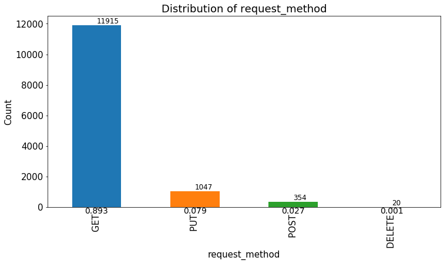

```python
#1. get distribution of request_method
get_bar_plot("request_method", daily_logs_app)
```

GET is most frequently called request_method, with 89%, while other three methods are totally 11%.

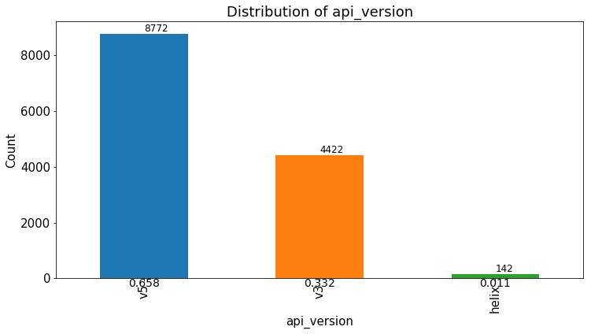

```python
#2. get distribution of API_version
get_bar_plot("api_version", daily_logs_app)
```

Now v5 is the most used API version(65%), since it is the current version, compared to old version v3 and new-released version helix. But since v5 and v3 will be removed in Dec 2018, the usage of helix will be largely increased in the future.

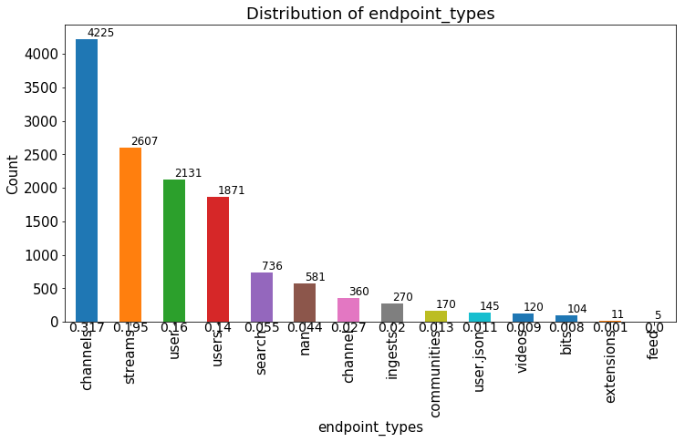

```python
#3. get distribution of endpoint_types
get_bar_plot("endpoint_types", daily_logs_app)
```

endpoint_types: channels, streams, user, users and search are top 5 popular endpoint_types, occupy 86%.

```python
#4.1 the combination of request_method and endpoint_types
print(daily_logs_app.groupby(['request_method', 'endpoint_types']).groups.keys())
print(len(daily_logs_app.groupby(['request_method', 'endpoint_types']).groups.keys()))
daily_logs_app.groupby(['request_method', 'endpoint_types'])['the_date']
```

```
dict_keys([('GET ', 'channels'), ('GET ', 'streams'), ('GET ', nan), ('GET ', 'search'), ('GET ', 'user'), ('GET ', 'user.json'), ('GET ', 'users'), ('GET ', 'channel'), ('PUT ', 'channels'), ('GET ', 'ingests'), ('GET ', 'communities'), ('POST ', 'channels'), ('GET ', 'videos'), ('PUT ', 'users'), …
19
```

```
request_method  endpoint_types
DELETE          channels            10
                users               10
GET             bits               104
                channel            360
                channels          2842
                communities        170
                extensions          11
                ingests            270
                search             736
                streams           2607
                user              2131
                user.json          145
                users             1838
                videos             120
POST            channels           349
                feed                 5
PUT             channels          1024
                users               23
Name: endpoint_types, dtype: int64
```

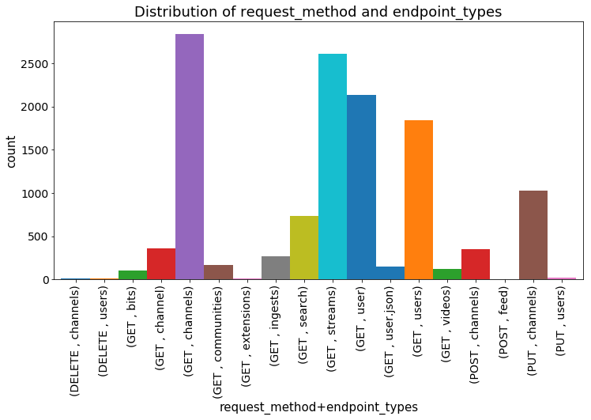

```python
#4.2 plot the combination of request_method and endpoint_types
get_two_group_plot('request_method', 'endpoint_types', 'bar', 'count', daily_logs_app)
```

```
request_method  api_version  endpoint_types
DELETE          v5           channels            10
                             users               10
GET             helix        streams             38
                             users              104
                v3           channel            180
                             channels           973
                             ingests             90
                             search             230
                             streams            958
                             user               980
                             user.json          145
                             users              235
                v5           bits               104
                             channel            180
                             channels          1869
                             communities        170
                             extensions          11
                             ingests            180
                             search             506
                             streams           1611
                             user              1151
                             users             1499
                             videos             120
POST            v3           channels            19
                v5           channels           330
                             feed                 5
PUT             v3           channels           128
                v5           channels           896
                             users               23
Name: api_version, dtype: int64
```

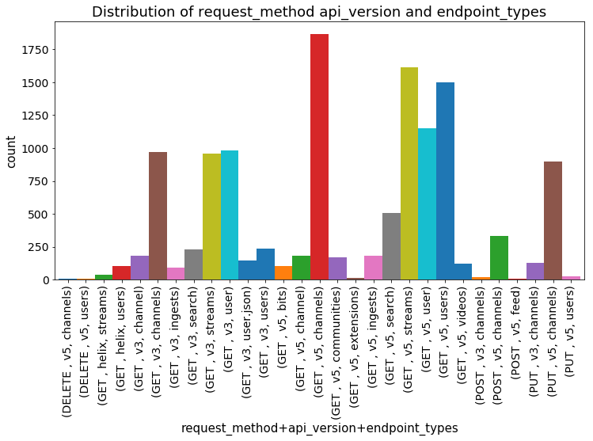

```python
#4.3 get API_endpoint
get_three_group_plot('request_method','api_version', 'endpoint_types', 'bar', 'count', daily_logs_app)
```

are most popular request_method and endpoint_method combination

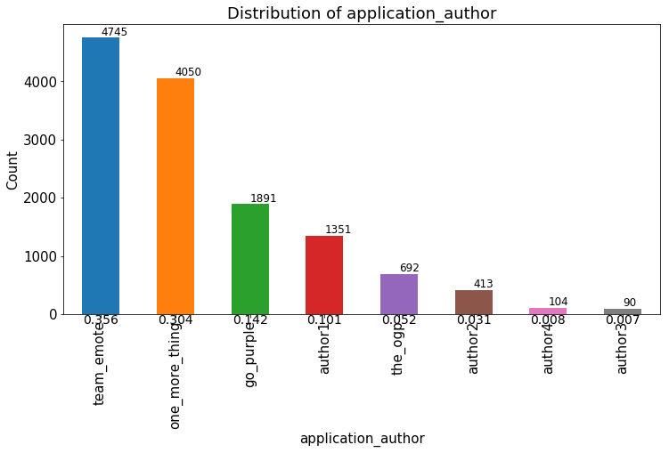

```python
#get distribution of application_author
get_bar_plot("application_author", daily_logs_app)
```

Author team_emote and one_more_thing have much more applications than other author

### 3.2 Date Relation(Trend of metrics and variables)

```python
def get_group_plot(v1, agg_v, df):
    fig = plt.figure(figsize = (12,6))
    ax = fig.add_subplot(111)
    gb = df.groupby(['the_date',v1])[v1].agg(agg_v).unstack()
    gb.plot(kind = 'line', ax = ax, width = 0.9)
    plt.title('Trend of ' + v1, fontsize = 18)
    plt.xlabel('The_date', fontsize = 15)
    plt.xticks(rotation = 'vertical')
    plt.ylabel('count', fontsize = 15)
    plt.xticks(fontsize = 14)
    plt.yticks(fontsize = 14)
    plt.legend(loc='center left', bbox_to_anchor=(1, 0.5), fontsize = 13)
    print(df.groupby(['the_date',v1])[v1].agg(agg_v).head(10))
```

```python
def get_two_group_plot(v1, v2, kind, agg_v, df):
    fig = plt.figure(figsize = (12,6))
    ax = fig.add_subplot(111)
    gb = df.groupby([v1, v2])[v2].agg(agg_v)
    gb.plot(kind = kind, ax = ax, width = 1)
    plt.title('Distribution of ' + v1 +" and "+ v2, fontsize = 18)
    plt.xlabel(v1 + "+" + v2, fontsize = 15)
    plt.xticks(rotation = 'vertical')
    plt.ylabel('count', fontsize = 15)
    plt.xticks(fontsize = 14)
    plt.yticks(fontsize = 14)
    #plt.legend(loc='center left', bbox_to_anchor=(1, 0.5), fontsize = 12)
    print(df.groupby([v1, v2])[v2].agg(agg_v))
```

```python
def get_three_group_plot(v1, v2,v3, kind, agg_v, df):
    fig = plt.figure(figsize = (12,6))
    ax = fig.add_subplot(111)
    gb = df.groupby([v1, v2, v3])[v2].agg(agg_v)
    gb.plot(kind = kind, ax = ax, width = 1)
    plt.title('Distribution of ' + v1 +' '+ v2 +" and "+ v3, fontsize = 18)
    plt.xlabel(v1 + "+" + v2 + "+" + v3 , fontsize = 15)
    plt.xticks(rotation = 'vertical')
    plt.ylabel('count', fontsize = 15)
    plt.xticks(fontsize = 14)
    plt.yticks(fontsize = 14)
    #plt.legend(loc='center left', bbox_to_anchor=(1, 0.5), fontsize = 12)
    print(df.groupby([v1, v2, v3])[v2].agg(agg_v))
```

```
the_date
2017-11-15    36967.167883
2017-11-16    37316.927007
2017-11-17    39561.161765
2017-11-18    41518.594203
2017-11-19    38946.591549
2017-11-20    38092.220588
2017-11-21    40425.725926
2017-11-22    37588.597315
2017-11-23    34601.863946
2017-11-24    36813.653061
Name: num_requests, dtype: float64
```

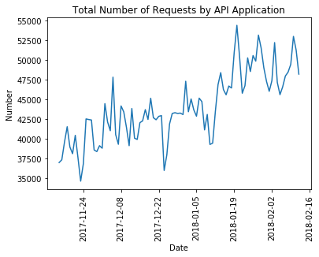

```python
#1. date with Num_requests
plt.title("Total Number of Requests by API Application")
plt.xlabel("Date")
plt.xticks(rotation= 'vertical')
plt.ylabel("Number")
g1 = daily_logs_app.groupby('the_date')['num_requests'].agg('mean')
plt.plot(g1)
daily_logs_app.groupby('the_date')['num_requests'].agg('mean').head(10)
```

Although there are obviously decrease during 17-11-23/17-12-24/18-01-10, but the general trend of number of request is increasing.

| the_date | mean | count |
| --- | --- | --- |
| 2017-11-15 | 125.489051 | 137 |
| 2017-11-16 | 126.379562 | 137 |
| 2017-11-17 | 131.433824 | 136 |
| 2017-11-18 | 129.913043 | 138 |
| 2017-11-19 | 120.640845 | 142 |
| 2017-11-20 | 134.529412 | 136 |
| 2017-11-21 | 122.674074 | 135 |
| 2017-11-22 | 124.805369 | 149 |
| 2017-11-23 | 110.755102 | 147 |
| 2017-11-24 | 112.523810 | 147 |

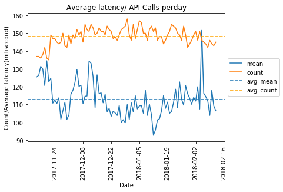

```python
#2. the date with avg_latency/API calls
fig = plt.figure()
ax = fig.add_subplot(111)
plt.title("Average latency/ API Calls perday")
plt.xlabel("Date")
plt.xticks(rotation = 'vertical')
plt.ylabel("Count/Average latency(milisecond)")
plt.plot(daily_logs_app.groupby('the_date')['avg_latency'].agg(['mean','count']))
plt.axhline(y = daily_logs_app['avg_latency'].mean(), linestyle = "--")
plt.axhline(y = daily_logs_app.groupby('the_date')['avg_latency'].agg('count').mean(), linestyle = "--", color = 'orange')
plt.legend(('mean', 'count', 'avg_mean', 'avg_count'), loc='center left', bbox_to_anchor=(1, 0.5))
daily_logs_app.groupby('the_date')['avg_latency'].agg(['mean','count']).head(10)
```

```
the_date    request_method
2017-11-15  GET               123
            POST                4
            PUT                10
2017-11-16  GET               123
            POST                3
            PUT                11
2017-11-17  GET               122
            POST                4
            PUT                10
2017-11-18  GET               125
Name: request_method, dtype: int64
```

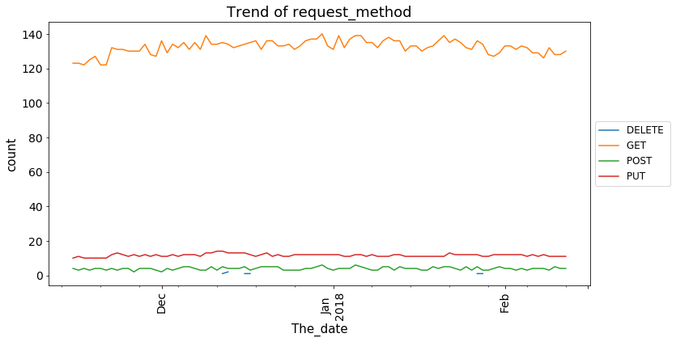

```python
#3. the date with request_method
get_group_plot('request_method', 'count', daily_logs_app)
```

The number of API calls slightly increased with narrow fluctuaction range, while the average latency has relatively large fluctuation and an extreme peak during 18-02-04, with the general trend decrease.

```
the_date    api_version
2017-11-15  helix           1
            v3             52
            v5             84
2017-11-16  helix           1
            v3             56
            v5             80
2017-11-17  helix           1
            v3             52
            v5             83
2017-11-18  helix           1
Name: api_version, dtype: int64
```

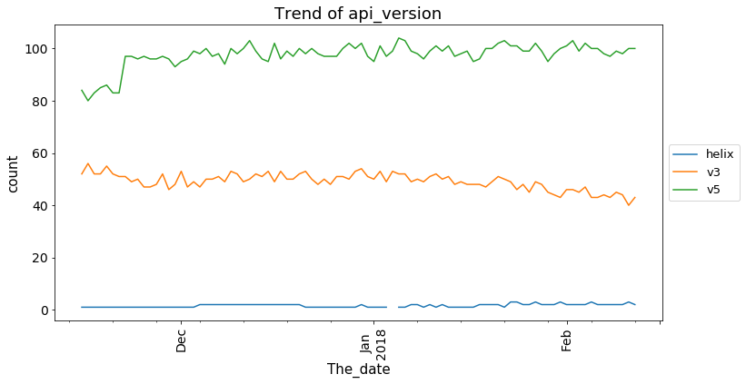

```python
#4. the date with API_version
get_group_plot('api_version', 'count', daily_logs_app)
```

Usage of v5 is increasing, of v3 is slightly decreasing, helix is slightly increasing.

```
the_date    endpoint_types
2017-11-15  bits               2
            channel            4
            channels          44
            communities        1
            ingests            3
            search             9
            streams           26
            user              24
            user.json          1
            users             16
Name: endpoint_types, dtype: int64
```

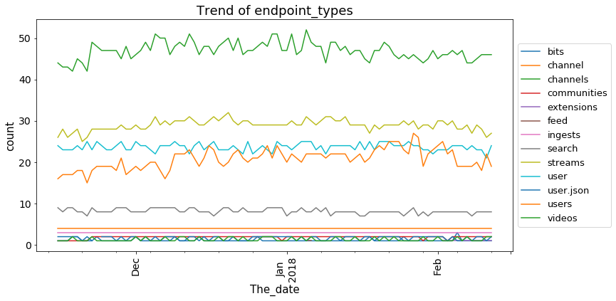

```python
#5. the date with endpoint_types
get_group_plot('endpoint_types', 'count', daily_logs_app)
```

```
the_date    application_author
2017-11-15  author1               16
            author2                6
            author3                1
            go_purple             19
            one_more_thing        44
            team_emote            41
            the_ogp               10
2017-11-16  author1               17
            author2                6
            author3                1
Name: application_author, dtype: int64
```

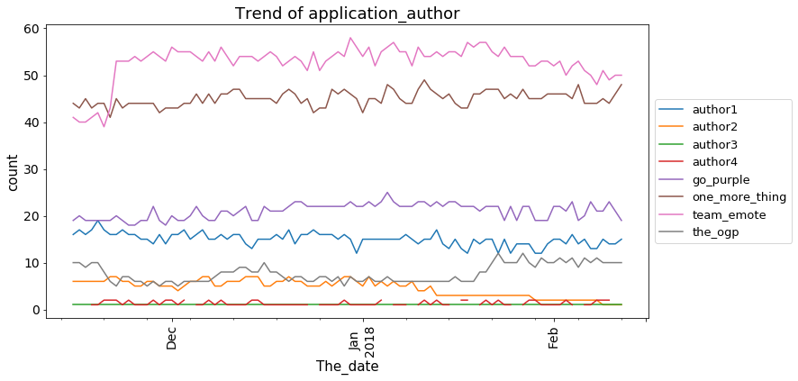

```python
#5. the date v.s. application name
get_group_plot('application_author', 'count', daily_logs_app)
```

Here we can see **one_more_thing** and **team_emote** are most popular author, with slightly increasing number of called. Unkown author1's applications are also being used frequently. While, applications for author2 decreased from low request rate to rare request. Along with applications of author3 and author4 are barely used.

### Summary of Time related(Trend) Analysis

As shown above, although with relatively large or small fluctuation, most variables kept the same trend during the last 3 months, with several variables slightly increase/decrease. Next, check the relationship between metrics and variables

### 3.3 Relationship between variables and num_request/avg_latency

how request_method/api_version/endpoint_types/application_author related to num_request/avg_latency quantitively?

#### One-to-One Relation

**NOTE:I want to show counts, the num_requests and avg_latency with variables, but they are not in the same quantity. We can normalized the groupby results, so that both can shown in one figure, give us better comparison.**

```python
'''
#get plot between num_request and avg_latency with variables
def get_one_group_plot(v1, kind, agg_v, df):

    ssn = df.groupby(v1)[['num_requests', 'avg_latency']].mean().sum()
    gb = df.groupby(v1)[['num_requests', 'avg_latency']].agg(agg_v)/ssn
    ax = gb.plot(kind = kind)
    plt.title('Relationship between ' + v1 +' and num_requests/avg_latency')
    plt.xlabel(v1)
    plt.xticks(rotation = 'vertical')
    plt.ylabel(agg_v + ' of num_requests/avg_latency(%)')
    plt.legend(loc='center left', bbox_to_anchor=(1, 0.5))
    print(gb)

'''
```

```python
#combine num_requests/avg_latency/counts into one figure
def get_one_group_plot(v1, kind, agg_v, df):
    fig = plt.figure(figsize = (12,6))
    ax = fig.add_subplot(111)
    ssn = df.groupby(v1)[['num_requests', 'avg_latency']].mean().sum()
    gb = df.groupby(v1)[['num_requests', 'avg_latency']].agg(agg_v)/ssn
    count = df[v1].value_counts()/df[v1].value_counts().sum()
    gb['count'] = count
    gb.plot(kind = kind, ax = ax, width = 0.9)
    plt.title('Relationship between ' + v1 +' and num_requests/avg_latency', fontsize = 18)
    plt.xlabel(v1, fontsize = 16)
    plt.xticks(fontsize = 16, rotation = 'vertical')
    plt.yticks(fontsize = 15)
    plt.ylabel(agg_v + '/count of num_requests/avg_latency(%)', fontsize = 15)
    plt.legend(loc='center left', bbox_to_anchor=(1, 0.5), fontsize = 15)
    print(gb)
```

```
                num_requests  avg_latency     count
request_method
DELETE              0.000024     0.123560  0.001500
GET                 0.999169     0.172229  0.893446
POST                0.000093     0.318497  0.026545
PUT                 0.000714     0.385713  0.078509
```

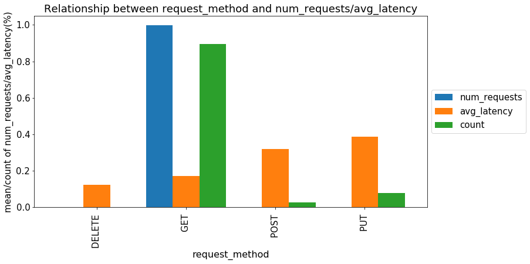

```python
#1.request_method
get_one_group_plot('request_method','bar', 'mean', daily_logs_app)
```

```
             num_requests  avg_latency     count
api_version
helix            0.129124     0.389590  0.010648
v3               0.134737     0.261042  0.331584
v5               0.736139     0.349367  0.657768
```

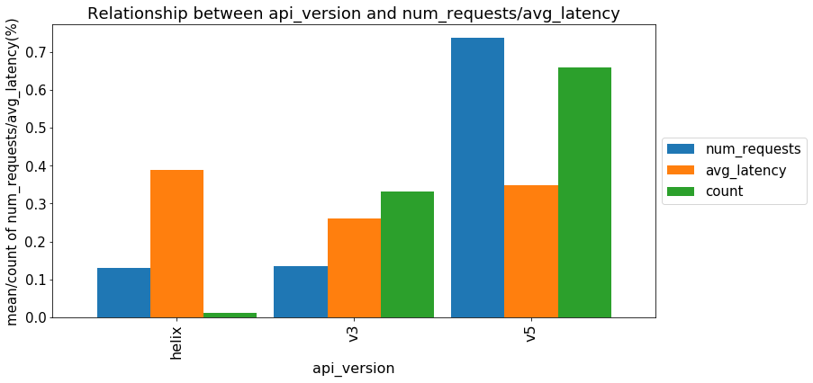

```python
#2. API_version
get_one_group_plot('api_version','bar', 'mean', daily_logs_app)
```

```
                    num_requests  avg_latency     count
application_author
author1                 0.025949     0.136365  0.101305
author2                 0.036461     0.068217  0.030969
author3                 0.000885     0.197201  0.006749
author4                 0.000013     0.059380  0.007798
go_purple               0.219075     0.117209  0.141797
one_more_thing          0.481776     0.144335  0.303689
team_emote              0.230027     0.097037  0.355804
the_ogp                 0.005815     0.180256  0.051890
```

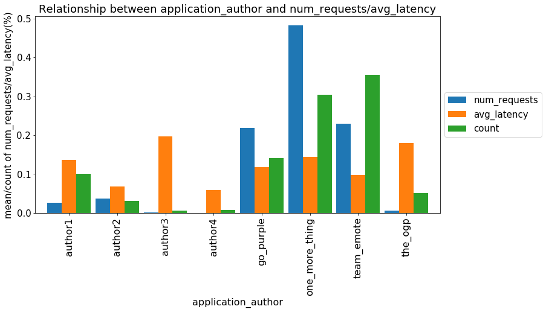

```python
#3. application_author
get_one_group_plot('application_author','bar', 'mean', daily_logs_app)
```

### One to two relationship

**Since groupby 2 or more variables, there are many the combinations, show the results in one figure might be not clear enough, so I redo seperately plot the relationship of num_requests/ avg_latency and other variables**

```python
#ONE# same as get_one, normalize the results, so that both can be shown in one figure
def get_multiple_group_plot(v1, v2, kind, agg_v, df):
    fig = plt.figure(figsize = (12,6))
    ax = fig.add_subplot(111)
    ssn = df.groupby([v1, v2])[['num_requests', 'avg_latency']].mean().sum()
    gb = (df.groupby([v1, v2])[['num_requests', 'avg_latency']].agg(agg_v)/ssn)
    gb.plot(kind = kind, ax = ax, width = 0.9)
    plt.title('Relationship of num_requests/avg_latency with ' + v1 +' and '+ v2, fontsize = 18)
    plt.xlabel(v1 + '+' + v2, fontsize = 15)
    plt.xticks(rotation = 'vertical', fontsize = 15)
    plt.ylabel(agg_v +' of num_requests/avg_latency (%)', fontsize = 15)
    plt.legend(loc='center left', bbox_to_anchor=(1, 0.5), fontsize = 15)
    print(gb)
```

```
                               num_requests  avg_latency
request_method endpoint_types
DELETE         channels            0.000004     0.025512
               users               0.000005     0.037058
GET            bits                0.021035     0.044543
               channel             0.000761     0.056991
               channels            0.495436     0.038274
               communities         0.000253     0.041888
               extensions          0.206809     0.021856
               ingests             0.000366     0.024928
               search              0.001830     0.038642
               streams             0.229208     0.043501
               user                0.002213     0.062887
               user.json           0.000009     0.024689
               users               0.041255     0.037035
               videos              0.000656     0.014360
POST           channels            0.000017     0.078387
               feed                0.000004     0.238086
PUT            channels            0.000129     0.098211
               users               0.000010     0.073153
```

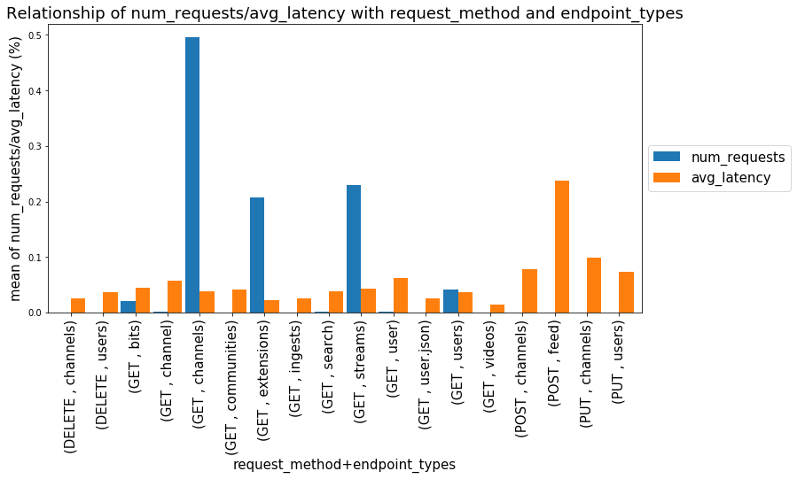

```python
get_multiple_group_plot('request_method', 'endpoint_types', 'bar', 'mean', daily_logs_app)
```

```python
#SEPARATE# same as get_one, normalize the results, so that both can be shown in one figure
def get_multiple_group_plot3(v1, v2,v3, kind, agg_v, df):
    fig = plt.figure(figsize = (12,6))
    ax = fig.add_subplot(111)
    ssn = df.groupby([v1, v2])[v3].mean().sum()
    gb = (df.groupby([v1, v2])[v3].agg(agg_v)/ssn)
    gb.plot(kind = kind, ax = ax, width = 0.9)
    plt.title('Relationship of '+ v3 + ' and '+ v1 +'/ '+ v2, fontsize = 18)
    plt.xlabel(v1 + '+' + v2, fontsize = 15)
    plt.xticks(rotation = 'vertical')
    plt.ylabel(agg_v +' of ' + v3+ '(%)', fontsize = 15)
    #plt.legend(loc='center left', bbox_to_anchor=(1, 0.5))
    print(gb)
```

```
request_method  endpoint_types
DELETE          channels          0.000004
                users             0.000005
GET             bits              0.021035
                channel           0.000761
                channels          0.495436
                communities       0.000253
                extensions        0.206809
                ingests           0.000366
                search            0.001830
                streams           0.229208
                user              0.002213
                user.json         0.000009
                users             0.041255
                videos            0.000656
POST            channels          0.000017
                feed              0.000004
PUT             channels          0.000129
                users             0.000010
Name: num_requests, dtype: float64
```

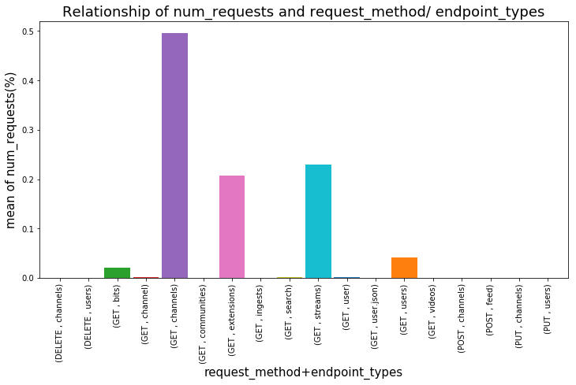

```python
#1. num_request with request_method + endpoint_types
get_multiple_group_plot3('request_method', 'endpoint_types','num_requests', 'bar', 'mean', daily_logs_app)
#unfortunately, plot both in one figure is more confusious... so for multiple group, plot respectively, but still can normalize the result
```

```
request_method  endpoint_types
DELETE          channels          0.025512
                users             0.037058
GET             bits              0.044543
                channel           0.056991
                channels          0.038274
                communities       0.041888
                extensions        0.021856
                ingests           0.024928
                search            0.038642
                streams           0.043501
                user              0.062887
                user.json         0.024689
                users             0.037035
                videos            0.014360
POST            channels          0.078387
                feed              0.238086
PUT             channels          0.098211
                users             0.073153
Name: avg_latency, dtype: float64
```

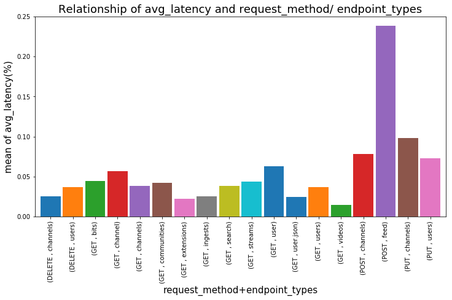

```python
#2. avg_latency with request_method + endpoint_types
get_multiple_group_plot3('request_method', 'endpoint_types','avg_latency', 'bar', 'mean', daily_logs_app)
```

### One to multiple relationship

```python
#3. relationship between num_requests/avg_latency and api_endpoints
#combination of API endpoint
print(daily_logs_app.groupby(['request_method', 'api_version','endpoint_types']).groups.keys())
print(len(daily_logs_app.groupby(['request_method', 'api_version','endpoint_types']).groups.keys()))
daily_logs_app.groupby(['request_method','api_version', 'endpoint_types'])[['num_requests', 'avg_latency']].agg('mean')
```

```
dict_keys([('GET ', 'v5', 'channels'), ('GET ', 'v5', 'streams'), ('GET ', 'v3', 'channels'), ('GET ', 'v3', nan), ('GET ', 'v3', 'search'), ('GET ', 'v3', 'user'), ('GET ', 'v3', 'user.json'), ('GET ', 'v3', 'streams'), ('GET ', 'v5', 'users'), ('GET ', 'v3', 'channel'), ('PUT ', 'v5', 'channels'),…
31
```

| request_method | api_version | endpoint_types | num_requests | avg_latency |
| --- | --- | --- | --- | --- |
| DELETE | v5 | channels | 1.000000 | 59.000000 |
|  |  | users | 1.400000 | 85.700000 |
| GET | helix | streams | 37556.815789 | 47.447368 |
|  |  | users | 910.750000 | 170.028846 |
|  | v3 | channel | 59.938889 | 119.533333 |
|  |  | channels | 32996.468654 | 71.849949 |
|  |  | ingests | 13.566667 | 41.822222 |
|  |  | search | 134.291304 | 48.104348 |
|  |  | streams | 13510.181628 | 85.453027 |
|  |  | user | 517.261224 | 125.677551 |
|  |  | user.json | 2.455172 | 57.096552 |
|  |  | users | 12.314894 | 49.765957 |
|  | v5 | bits | 5860.711538 | 103.009615 |
|  |  | channel | 364.161111 | 144.061111 |
|  |  | channels | 192723.253077 | 97.187801 |
|  |  | communities | 70.617647 | 96.870588 |
|  |  | extensions | 57621.181818 | 50.545455 |
|  |  | ingests | 146.044444 | 65.561111 |
|  |  | search | 680.671937 | 108.118577 |
|  |  | streams | 94424.534451 | 110.862197 |
|  |  | user | 701.177237 | 162.255430 |
|  |  | users | 14028.852568 | 85.418946 |
|  |  | videos | 182.900000 | 33.208333 |
| POST | v3 | channels | 3.736842 | 123.789474 |
|  | v5 | channels | 4.669697 | 184.587879 |
|  |  | feed | 1.000000 | 550.600000 |
| PUT | v3 | channels | 4.382812 | 248.062500 |
|  | v5 | channels | 40.456473 | 224.133929 |
|  |  | users | 2.826087 | 169.173913 |

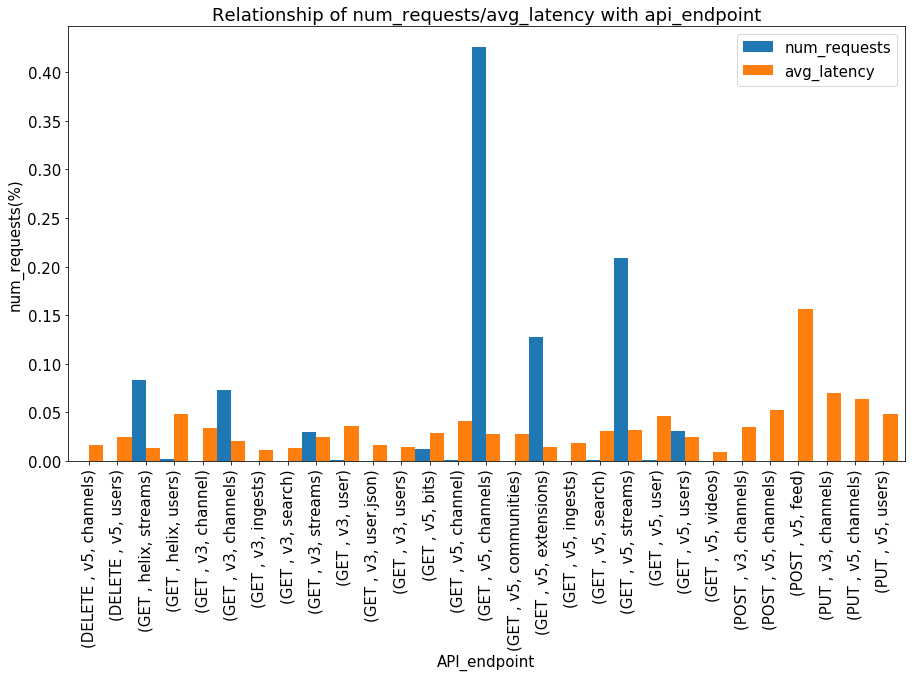

```python
#plot the relationship
fig = plt.figure(figsize = (15,8))
ax = fig.add_subplot(111)
ssn = daily_logs_app.groupby(['request_method','api_version', 'endpoint_types'])[['num_requests', 'avg_latency']].mean().sum()
gb = daily_logs_app.groupby(['request_method','api_version', 'endpoint_types'])[['num_requests', 'avg_latency']].agg('mean')/ssn
gb.plot(ax =ax, kind = 'bar', width = 1)
plt.title('Relationship of num_requests/avg_latency with api_endpoint', fontsize = 18)
plt.xlabel('API_endpoint', fontsize = 15)
plt.xticks(fontsize = 15)
plt.yticks(fontsize = 15)
plt.ylabel('num_requests(%)', fontsize = 15)
plt.legend(fontsize = 15)
#plt.savefig('E:/update/Interviews/twitch/na_api.png')
```

[output not shown]

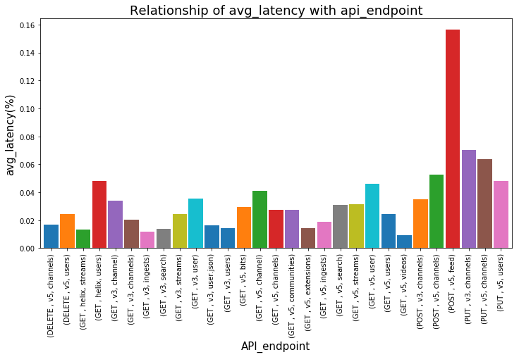

```python
#4. avg_latency with API_endpoints
fig = plt.figure(figsize = (12,6))
ax = fig.add_subplot(111)
ssn = daily_logs_app.groupby(['request_method','api_version', 'endpoint_types'])['avg_latency'].mean().sum()
gb = daily_logs_app.groupby(['request_method','api_version', 'endpoint_types'])['avg_latency'].agg('mean')/ssn
gb.plot(kind = 'bar', ax = ax, width = 0.9)
plt.title('Relationship of avg_latency with api_endpoint', fontsize = 18)
plt.xlabel('API_endpoint', fontsize = 15)
#plt.xticks(rotation = 'vertical')
plt.ylabel('avg_latency(%)', fontsize = 15)
#plt.legend(loc='center left', bbox_to_anchor=(1, 0.5))
```